# One-Hot Encoding and Missingness

# Acquire and Read the data

The dataset used for this analysis is an extraction from the 1994 census data by Barry Becker and donated to the public site http://archive.ics.uci.edu/ml/datasets/Census+Income.

This dataset is called the **Adult** dataset. It contains 15 columns and each row represents an individual.There is a total of 16,281 individuals. Some columns such as **Age** and **Occupation** are self-explanatory. **fnlwgt** is the final weight determined by Census Org, **Education-Num** is the number of years of education, **CapitalGain** and **CapitalLoss** are the capital gain and loss made by the individual respectively, **HoursperWeek** is the average number of hours spent by the individual on work.

The **Adult** dataset is given by:

```r
testFileName = "adult.test"

if (!file.exists(testFileName))
    download.file(url = "http://archive.ics.uci.edu/ml/machine-learning-databases/adult/adult.test",
                   destfile = testFileName)

colNames = c("Age", "WorkClass", "fnlwgt", "Education",
              "EducationNum", "MaritalStatus", "Occupation",
              "Relationship", "Race", "Sex", "CapitalGain",
              "CapitalLoss", "HoursperWeek", "NativeCountry",
              "IncomeLevel")

adult_test_raw = read.table (testFileName, header = TRUE, sep = ",",
                       strip.white = TRUE, col.names = colNames,
                        stringsAsFactors = TRUE)

adult_test = read.table (testFileName, header = TRUE, sep = ",",
                       strip.white = TRUE, col.names = colNames,
                        na.strings = "?", stringsAsFactors = TRUE)

kable(head(adult_test_raw), booktabs = TRUE) %>%
  kable_styling(font_size = 9)
```

| Age | WorkClass | fnlwgt | Education | EducationNum | MaritalStatus | Occupation | Relationship | Race | Sex | CapitalGain | CapitalLoss | HoursperWeek | NativeCountry | IncomeLevel |
| --- | --- | --- | --- | --- | --- | --- | --- | --- | --- | --- | --- | --- | --- | --- |
| 25 | Private | 226802 | 11th | 7 | Never-married | Machine-op-inspct | Own-child | Black | Male | 0 | 0 | 40 | United-States | <=50K. |
| 38 | Private | 89814 | HS-grad | 9 | Married-civ-spouse | Farming-fishing | Husband | White | Male | 0 | 0 | 50 | United-States | <=50K. |
| 28 | Local-gov | 336951 | Assoc-acdm | 12 | Married-civ-spouse | Protective-serv | Husband | White | Male | 0 | 0 | 40 | United-States | >50K. |
| 44 | Private | 160323 | Some-college | 10 | Married-civ-spouse | Machine-op-inspct | Husband | Black | Male | 7688 | 0 | 40 | United-States | >50K. |
| 18 | ? | 103497 | Some-college | 10 | Never-married | ? | Own-child | White | Female | 0 | 0 | 30 | United-States | <=50K. |
| 34 | Private | 198693 | 10th | 6 | Never-married | Other-service | Not-in-family | White | Male | 0 | 0 | 30 | United-States | <=50K. |

Reading the dataset in its raw form, `adult_test_raw` has no missing data. However factors such as **Occupation**, **NativeCountry** and **WorkClass** have “?” as a level.

```r
str(adult_test_raw)
```

```
## 'data.frame':    16281 obs. of  15 variables:
##  $ Age          : int  25 38 28 44 18 34 29 63 24 55 ...
##  $ WorkClass    : Factor w/ 9 levels "?","Federal-gov",..: 5 5 3 5 1 5 1 7 5 5 ...
##  $ fnlwgt       : int  226802 89814 336951 160323 103497 198693 227026 104626 369667 104996 ...
##  $ Education    : Factor w/ 16 levels "10th","11th",..: 2 12 8 16 16 1 12 15 16 6 ...
##  $ EducationNum : int  7 9 12 10 10 6 9 15 10 4 ...
##  $ MaritalStatus: Factor w/ 7 levels "Divorced","Married-AF-spouse",..: 5 3 3 3 5 5 5 3 5 3 ...
##  $ Occupation   : Factor w/ 15 levels "?","Adm-clerical",..: 8 6 12 8 1 9 1 11 9 4 ...
##  $ Relationship : Factor w/ 6 levels "Husband","Not-in-family",..: 4 1 1 1 4 2 5 1 5 1 ...
##  $ Race         : Factor w/ 5 levels "Amer-Indian-Eskimo",..: 3 5 5 3 5 5 3 5 5 5 ...
##  $ Sex          : Factor w/ 2 levels "Female","Male": 2 2 2 2 1 2 2 2 1 2 ...
##  $ CapitalGain  : int  0 0 0 7688 0 0 0 3103 0 0 ...
##  $ CapitalLoss  : int  0 0 0 0 0 0 0 0 0 0 ...
##  $ HoursperWeek : int  40 50 40 40 30 30 40 32 40 10 ...
##  $ NativeCountry: Factor w/ 41 levels "?","Cambodia",..: 39 39 39 39 39 39 39 39 39 39 ...
##  $ IncomeLevel  : Factor w/ 2 levels "<=50K.",">50K.": 1 1 2 2 1 1 1 2 1 1 ...
```

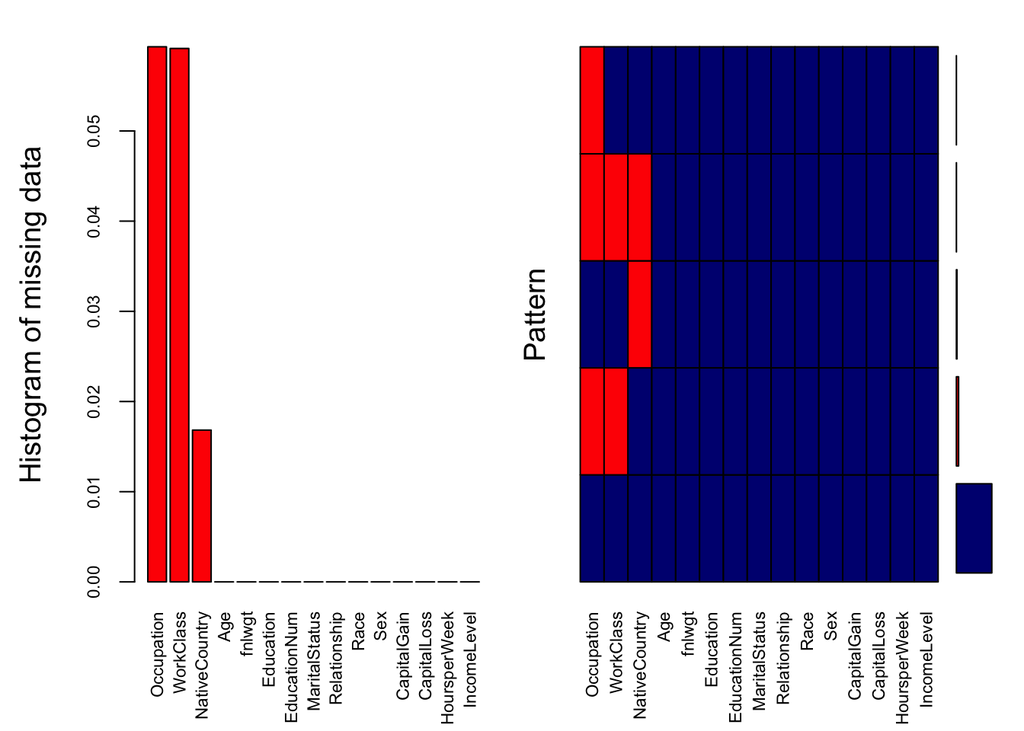

```
##
##  Variables sorted by number of missings:
##       Variable      Count
##     Occupation 0.05933296
##      WorkClass 0.05914870
##  NativeCountry 0.01682943
##            Age 0.00000000
##         fnlwgt 0.00000000
##      Education 0.00000000
##   EducationNum 0.00000000
##  MaritalStatus 0.00000000
##   Relationship 0.00000000
##           Race 0.00000000
##            Sex 0.00000000
##    CapitalGain 0.00000000
##    CapitalLoss 0.00000000
##   HoursperWeek 0.00000000
##    IncomeLevel 0.00000000
```

```r
aggr_plot <- aggr(adult_test, col=c('navyblue','red'), numbers=TRUE, sortVars=TRUE, labels=names(adult_test), cex.axis=.7, gap=3, ylab=c("Histogram of missing data","Pattern"))
```

# One-hot encoding

The columns with factor values are separated from the `adult_test` dataset so that **One-hot encoding** can encode the factors and transform the data into a numeric matrix. `adult_test_chars` has 16,281 rows and 9 columns. One row for each individual in the original `adult_test` dataset. The 9 columns are the 9 factors present in the data:

```r
adult_test_chars <- adult_test %>%
             select_if(is.factor)

kable(head(adult_test_chars), booktabs = TRUE) %>%
  kable_styling(font_size = 10)
```

| WorkClass | Education | MaritalStatus | Occupation | Relationship | Race | Sex | NativeCountry | IncomeLevel |
| --- | --- | --- | --- | --- | --- | --- | --- | --- |
| Private | 11th | Never-married | Machine-op-inspct | Own-child | Black | Male | United-States | <=50K. |
| Private | HS-grad | Married-civ-spouse | Farming-fishing | Husband | White | Male | United-States | <=50K. |
| Local-gov | Assoc-acdm | Married-civ-spouse | Protective-serv | Husband | White | Male | United-States | >50K. |
| Private | Some-college | Married-civ-spouse | Machine-op-inspct | Husband | Black | Male | United-States | >50K. |
| NA | Some-college | Never-married | NA | Own-child | White | Female | United-States | <=50K. |
| Private | 10th | Never-married | Other-service | Not-in-family | White | Male | United-States | <=50K. |

For illustration purposes, only **Race** with 5 factors and **Sex** with 2 factors are transformed. After transforming the data, the **One-hot encoding** dataset has 7 columns with 1s and 0s as numeric values only. The 7 columns represent the combinations of factors for each row in the original `adult_test` dataset:

```r
ohe <- dummyVars(" ~ .", data = adult_test_chars[,c("Race","Sex")])
subset_ohe <- data.frame(predict(ohe, newdata = adult_test_chars[,c("Race","Sex")]))

colnames(subset_ohe)
```

```
## [1] "Race.Amer.Indian.Eskimo" "Race.Asian.Pac.Islander"
## [3] "Race.Black"              "Race.Other"
## [5] "Race.White"              "Sex.Female"
## [7] "Sex.Male"
```

For instance, the individual in the first row of the `adult_test` dataset has $Race=black$ and $Sex=Male$. The first row in the **One-hot encoding** `subset_ohe` dataset has $Race.Black=1$ and $Sex.Male=1$, as expected.

```r
kable(head(subset_ohe), booktabs = TRUE) %>%
  kable_styling(font_size = 10)
```

| Race.Amer.Indian.Eskimo | Race.Asian.Pac.Islander | Race.Black | Race.Other | Race.White | Sex.Female | Sex.Male |
| --- | --- | --- | --- | --- | --- | --- |
| 0 | 0 | 1 | 0 | 0 | 0 | 1 |
| 0 | 0 | 0 | 0 | 1 | 0 | 1 |
| 0 | 0 | 0 | 0 | 1 | 0 | 1 |
| 0 | 0 | 1 | 0 | 0 | 0 | 1 |
| 0 | 0 | 0 | 0 | 1 | 1 | 0 |
| 0 | 0 | 0 | 0 | 1 | 0 | 1 |

After transforming the entire data, the **One-hot encoding** dataset has 100 columns with 1s and 0s as numeric values only, and 16,281 rows. The 100 columns represent the combinations of all levels of the 9 factors. Each row is each individual in the original `adult_test` dataset:

```r
adult_test %>%
  select_if(is.factor) %>%
  sapply(levels)
```

```
## $WorkClass
## [1] "Federal-gov"      "Local-gov"        "Never-worked"
## [4] "Private"          "Self-emp-inc"     "Self-emp-not-inc"
## [7] "State-gov"        "Without-pay"
##
## $Education
##  [1] "10th"         "11th"         "12th"         "1st-4th"
##  [5] "5th-6th"      "7th-8th"      "9th"          "Assoc-acdm"
##  [9] "Assoc-voc"    "Bachelors"    "Doctorate"    "HS-grad"
## [13] "Masters"      "Preschool"    "Prof-school"  "Some-college"
##
## $MaritalStatus
## [1] "Divorced"              "Married-AF-spouse"     "Married-civ-spouse"
## [4] "Married-spouse-absent" "Never-married"         "Separated"
## [7] "Widowed"
```

[output cut: 43 more lines]

Some of the factor columns in the numeric matrix `test_ohe` are illustrate below:

```r
ohe <- dummyVars(" ~ .", data = adult_test_chars)
test_ohe <- data.frame(predict(ohe, newdata = adult_test_chars))

dim(test_ohe)
```

```
## [1] 16281   100
```

```r
car::some(colnames(test_ohe), 20)
```

```
##  [1] "WorkClass.Federal.gov"            "Education.Bachelors"
##  [3] "Education.HS.grad"                "Education.Masters"
##  [5] "Occupation.Craft.repair"          "Occupation.Other.service"
##  [7] "Occupation.Prof.specialty"        "Occupation.Protective.serv"
##  [9] "Occupation.Tech.support"          "Relationship.Husband"
## [11] "NativeCountry.Cambodia"           "NativeCountry.China"
## [13] "NativeCountry.Dominican.Republic" "NativeCountry.England"
## [15] "NativeCountry.Hong"               "NativeCountry.Mexico"
## [17] "NativeCountry.Philippines"        "NativeCountry.Poland"
## [19] "NativeCountry.Taiwan"             "IncomeLevel..50K."
```

Once again, the individual in the first row of the `adult_test` dataset has $WorkClass=Private$. The first row in the **One-hot encoding** `test_ohe` dataset has $WorkClass.Private=1$ and so on and so forth for the remaining columns. Notice the fifth individuals has missing values in the `adult_test` dataset. For this reason, the fifth row in `test_ohe` has all missing values.

```r
kable(head(test_ohe[,1:8]), booktabs = TRUE) %>%
  kable_styling(font_size = 9)
```

| WorkClass.Federal.gov | WorkClass.Local.gov | WorkClass.Never.worked | WorkClass.Private | WorkClass.Self.emp.inc | WorkClass.Self.emp.not.inc | WorkClass.State.gov | WorkClass.Without.pay |
| --- | --- | --- | --- | --- | --- | --- | --- |
| 0 | 0 | 0 | 1 | 0 | 0 | 0 | 0 |
| 0 | 0 | 0 | 1 | 0 | 0 | 0 | 0 |
| 0 | 1 | 0 | 0 | 0 | 0 | 0 | 0 |
| 0 | 0 | 0 | 1 | 0 | 0 | 0 | 0 |
| NA | NA | NA | NA | NA | NA | NA | NA |
| 0 | 0 | 0 | 1 | 0 | 0 | 0 | 0 |